# Homework 6

PSTAT 131/231

## Tree-Based Models

For this assignment, we will continue working with the file `"pokemon.csv"`, found in `/data`. The file is from Kaggle: https://www.kaggle.com/abcsds/pokemon.

The [Pokémon](https://www.pokemon.com/us/) franchise encompasses video games, TV shows, movies, books, and a card game. This data set was drawn from the video game series and contains statistics about 721 Pokémon, or “pocket monsters.” In Pokémon games, the user plays as a trainer who collects, trades, and battles Pokémon to (a) collect all the Pokémon and (b) become the champion Pokémon trainer.

Each Pokémon has a [primary type](https://bulbapedia.bulbagarden.net/wiki/Type) (some even have secondary types). Based on their type, a Pokémon is strong against some types, and vulnerable to others. (Think rock, paper, scissors.) A Fire-type Pokémon, for example, is vulnerable to Water-type Pokémon, but strong against Grass-type.

The goal of this assignment is to build a statistical learning model that can predict the **primary type** of a Pokémon based on its generation, legendary status, and six battle statistics.

**Note: Fitting ensemble tree-based models can take a little while to run. Consider running your models outside of the .Rmd, storing the results, and loading them in your .Rmd to minimize time to knit.**

```r
library(tidymodels)
library(tidyverse)
library(ISLR)
library(ISLR2)
library(rpart.plot)
library(vip)
library(janitor)
library(randomForest)
library(xgboost)
library(tidyverse)
library(glmnet)
tidymodels_prefer()
```

### Exercise 1

Read in the data and set things up as in Homework 5:

- Use `clean_names()`
- Filter out the rarer Pokémon types
- Convert `type_1` and `legendary` to factors

```r
library(janitor)

data<- read.csv("Pokemon.csv")

# use clean_names()
data1 <- clean_names(data)
data1
```

[output not shown]

[output cut: 1587 more lines]

```r
# filter out the rarer Pokemon types
table(data1$type_1)
```

```
##
##      Bug     Dark   Dragon Electric    Fairy Fighting     Fire   Flying
##       69       31       32       44       17       27       52        4
##    Ghost    Grass   Ground      Ice   Normal   Poison  Psychic     Rock
##       32       70       32       24       98       28       57       44
##    Steel    Water
##       27      112
```

```r
data2 <- filter(data1, type_1 != "Flying")

# convert type_1 and legendary to factors
data2 <- data2 %>%
  mutate(type_1 = factor(type_1), legendary = factor(legendary))

data2
```

[output not shown]

[output cut: 1579 more lines]

Do an initial split of the data; you can choose the percentage for splitting. Stratify on the outcome variable.

```r
set.seed(1234)
data2_split <- initial_split(data2, strata = "type_1", prop = 0.7)

data_train <- training(data2_split)
data_test <- testing(data2_split)

dim(data_train)
```

```
## [1] 556  13
```

```r
dim(data_test)
```

```
## [1] 240  13
```

```r
data_train
```

[output not shown]

[output cut: 1099 more lines]

Fold the training set using *v*-fold cross-validation, with `v = 5`. Stratify on the outcome variable.

```r
set.seed(1234)
data_fold <- vfold_cv(data_train, v = 5, strata = type_1)
```

Set up a recipe to predict `type_1` with `legendary`, `generation`, `sp_atk`, `attack`, `speed`, `defense`, `hp`, and `sp_def`:

- Dummy-code `legendary` and `generation`;
- Center and scale all predictors.

```r
data_recipe <- recipe(type_1 ~ legendary + generation + sp_atk + attack + speed + defense + hp + sp_def, data = data_train) %>%
  step_dummy(c(legendary, generation)) %>%
  step_normalize(all_predictors())
```

### Exercise 2

Create a correlation matrix of the training set, using the `corrplot` package. *Note: You can choose how to handle the continuous variables for this plot; justify your decision(s).*

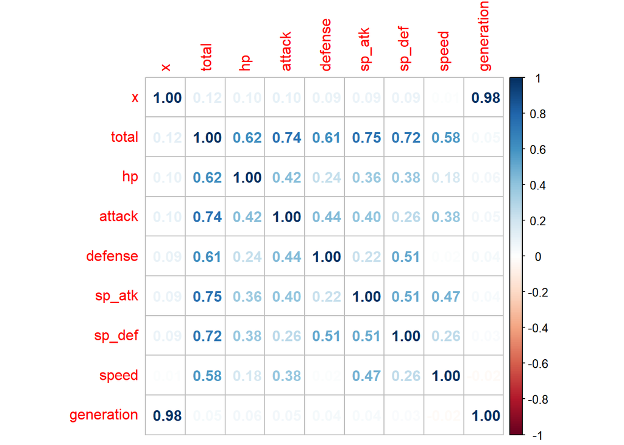

```r
library(corrplot)
# I handled the continuous variables to be deleted for this correlation plot.
data_train2 <- select(data1,-name, -type_1, -type_2,-legendary)
cor_matirx = cor(data_train2)
corrplot(cor_matirx, method = "num")
```

What relationships, if any, do you notice? Do these relationships make sense to you? –> ‘total’ and ‘attack’, ‘sp_atk’, ‘sp_def’ are in high correlated. These relationships make sense because ‘total’ variable is the sum of ‘attack’, ‘sp_atk’, ‘sp_def’, ‘hp’, ‘defense’, ‘speed’. The important things of Pokemon’s ability seem ‘attack’, ‘sp_atk’, and ‘sp_def’.

### Exercise 3

First, set up a decision tree model and workflow. Tune the `cost_complexity` hyperparameter. Use the same levels we used in Lab 7 – that is, `range = c(-3, -1)`. Specify that the metric we want to optimize is `roc_auc`.

```r
# Set up a decision tree model
tree_spec <- decision_tree() %>%
  set_engine("rpart")

class_tree_spec <- tree_spec %>%
  set_mode("classification")


# Set up a decision tree workflow
class_tree_wf <- workflow() %>%
  add_model(class_tree_spec %>% set_args(cost_complexity = tune())) %>%
  add_recipe(data_recipe)

# Tune the 'cost_complexity' hyperparameter.
set.seed(1234)

param_grid <- grid_regular(cost_complexity(range = c(-3, -1)), levels = 10)

param_grid
```

```
## # A tibble: 10 × 1
##    cost_complexity
##              <dbl>
##  1         0.001
##  2         0.00167
##  3         0.00278
##  4         0.00464
##  5         0.00774
##  6         0.0129
##  7         0.0215
##  8         0.0359
##  9         0.0599
## 10         0.1
```

```r
tune_res <- tune_grid(
  class_tree_wf,
  resamples = data_fold,
  grid = param_grid,
  metrics = metric_set(roc_auc)
)
```

Print an `autoplot()` of the results. What do you observe? Does a single decision tree perform better with a smaller or larger complexity penalty?

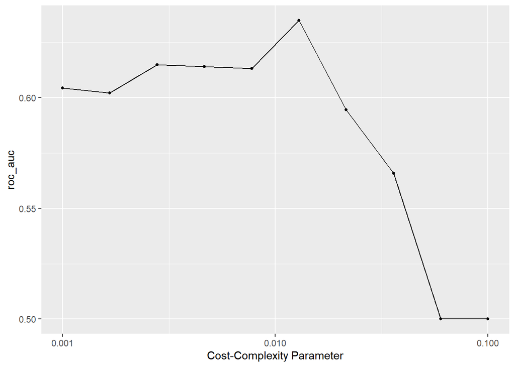

```r
autoplot(tune_res)
```

–> I can observe that roc_auc is the highest when the complexity penalty is about 0.010. A single decision tree performs better with a smaller complexity penalty than a larger one.

### Exercise 4

What is the `roc_auc` of your best-performing pruned decision tree on the folds? *Hint: Use `collect_metrics()` and `arrange()`.*

```r
collect_metrics(tune_res) %>%
  arrange(- mean)
```

```
## # A tibble: 10 × 7
##    cost_complexity .metric .estimator  mean     n std_err .config
##              <dbl> <chr>   <chr>      <dbl> <int>   <dbl> <chr>
##  1         0.0129  roc_auc hand_till  0.635     5 0.00622 Preprocessor1_Model06
##  2         0.00278 roc_auc hand_till  0.615     5 0.0127  Preprocessor1_Model03
##  3         0.00464 roc_auc hand_till  0.614     5 0.0117  Preprocessor1_Model04
##  4         0.00774 roc_auc hand_till  0.613     5 0.00821 Preprocessor1_Model05
##  5         0.001   roc_auc hand_till  0.604     5 0.0132  Preprocessor1_Model01
##  6         0.00167 roc_auc hand_till  0.602     5 0.0125  Preprocessor1_Model02
##  7         0.0215  roc_auc hand_till  0.595     5 0.0171  Preprocessor1_Model07
##  8         0.0359  roc_auc hand_till  0.566     5 0.0227  Preprocessor1_Model08
##  9         0.0599  roc_auc hand_till  0.5       5 0       Preprocessor1_Model09
## 10         0.1     roc_auc hand_till  0.5       5 0       Preprocessor1_Model10
```

–> The ‘roc_auc’ of my best-performing pruned decision tree on the folds is ‘0.6348932’.

### Exercise 5

Using `rpart.plot`, fit and visualize your best-performing pruned decision tree with the *training* set.

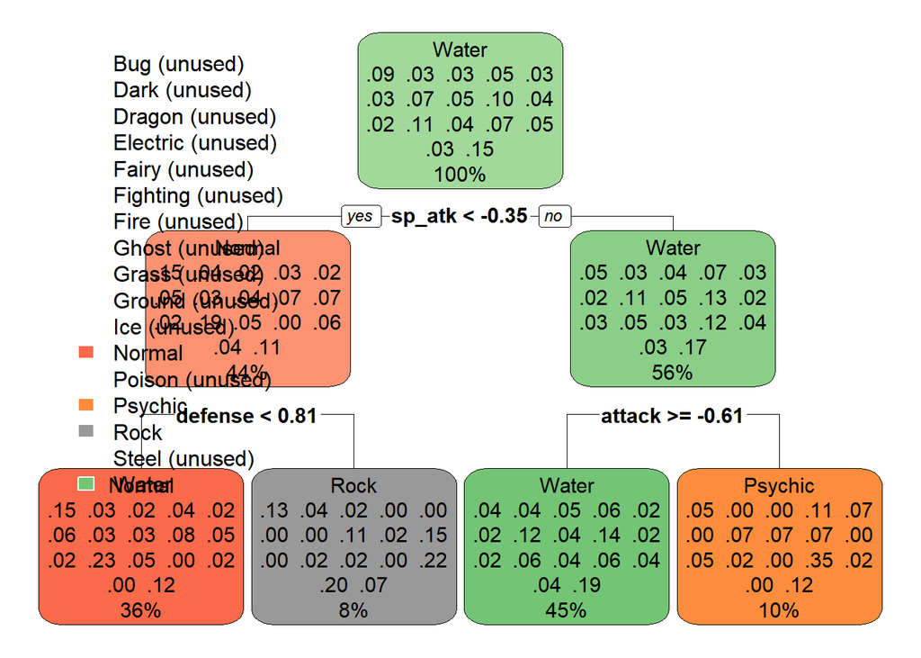

```r
# fit my best_performing pruned decision tree with the training set.
best_complexity <- select_best(tune_res, metric = "roc_auc")
class_tree_final <- finalize_workflow(class_tree_wf, best_complexity)
class_tree_final_fit <- fit(class_tree_final, data = data_train)

# visualize my best_performing pruned decision tree with the training set.
class_tree_final_fit %>%
  extract_fit_engine() %>%
  rpart.plot(roundint=FALSE)
```

### Exercise 5

Now set up a random forest model and workflow. Use the `ranger` engine and set `importance = "impurity"`. Tune `mtry`, `trees`, and `min_n`. Using the documentation for `rand_forest()`, explain in your own words what each of these hyperparameters represent.

Create a regular grid with 8 levels each. You can choose plausible ranges for each hyperparameter. Note that `mtry` should not be smaller than 1 or larger than 8. **Explain why not. What type of model would `mtry = 8` represent?**

```r
rf_spec <- rand_forest(mtry = tune(), trees = tune(), min_n = tune()) %>%
  set_engine("ranger", importance = "impurity") %>%
  set_mode("classification")

data_recipe2 <- recipe(type_1 ~ legendary + generation + sp_atk + attack + speed + defense + hp + sp_def, data = data_train) %>%
  step_unknown() %>%
  step_dummy(c(legendary, generation)) %>%
  step_normalize(all_predictors())

rf_wf <- workflow() %>%
  add_model(rf_spec) %>%
  add_recipe(data_recipe2)
```

```r
set.seed(1234)
param_grid2 <- grid_regular(mtry(range = c(1, 8)), trees(range = c(10,100)) , min_n(range = c(10,100)), levels = 8)
param_grid2
```

```
## # A tibble: 512 × 3
##     mtry trees min_n
##    <int> <int> <int>
##  1     1    10    10
##  2     2    10    10
##  3     3    10    10
##  4     4    10    10
##  5     5    10    10
##  6     6    10    10
##  7     7    10    10
##  8     8    10    10
##  9     1    22    10
## 10     2    22    10
## # … with 502 more rows
```

–> ‘mtry’ hyperparameter is the number of randomly selected predictors. ‘trees’ hyperparameter is the number of threes. And ‘min_n’ hyperparameter is the minimal node size. The reason why ‘mtry’ should not be smaller than 1 or larger than 8 is that we have only 8 predictors. ‘mtry’ hyperparameter is the number of randomly selected predictors. The type of model `mtry = 8` would represent the the model that all of the predictors are selected.

### Exercise 6

Specify `roc_auc` as a metric. Tune the model and print an `autoplot()` of the results. What do you observe? What values of the hyperparameters seem to yield the best performance?

```r
tune_res2 <- tune_grid(
  rf_wf,
  resamples = data_fold,
  grid = param_grid2,
  metrics = metric_set(roc_auc)
)
```

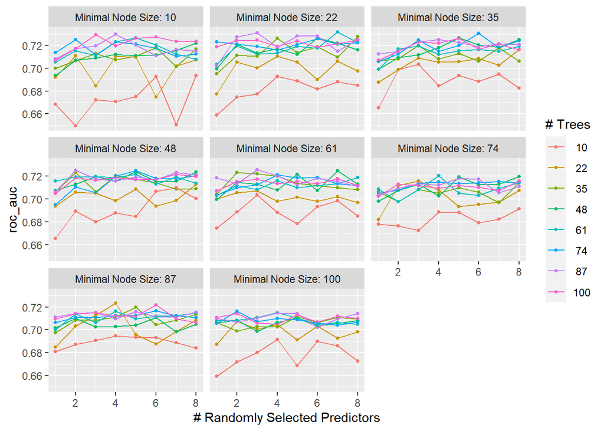

```r
autoplot(tune_res2)
```

—> I can observe that when ‘mtry’ hyperparameter is 7, ‘trees’ parameter is 61, and ‘min_n’ hyperparameter is 22, the model seems to yield the best performance.

### Exercise 7

What is the `roc_auc` of your best-performing random forest model on the folds? *Hint: Use `collect_metrics()` and `arrange()`.*

```r
collect_metrics(tune_res2) %>%
  arrange(- mean)
```

```
## # A tibble: 512 × 9
##     mtry trees min_n .metric .estimator  mean     n std_err .config
##    <int> <int> <int> <chr>   <chr>      <dbl> <int>   <dbl> <chr>
##  1     7    61    22 roc_auc hand_till  0.732     5 0.00921 Preprocessor1_Model…
##  2     3    87    22 roc_auc hand_till  0.731     5 0.00862 Preprocessor1_Model…
##  3     6    74    35 roc_auc hand_till  0.730     5 0.00681 Preprocessor1_Model…
##  4     4    87    10 roc_auc hand_till  0.730     5 0.00913 Preprocessor1_Model…
##  5     3   100    10 roc_auc hand_till  0.730     5 0.0102  Preprocessor1_Model…
##  6     6    87    22 roc_auc hand_till  0.728     5 0.00741 Preprocessor1_Model…
##  7     5    87    22 roc_auc hand_till  0.728     5 0.0107  Preprocessor1_Model…
##  8     8    35    22 roc_auc hand_till  0.728     5 0.0101  Preprocessor1_Model…
##  9     6   100    10 roc_auc hand_till  0.727     5 0.00513 Preprocessor1_Model…
## 10     2    87    22 roc_auc hand_till  0.727     5 0.0125  Preprocessor1_Model…
## # … with 502 more rows
```

–> The `roc_auc` of my best-performing random forest model on the folds is ‘0.7318138’.

### Exercise 8

Create a variable importance plot, using `vip()`, with your best-performing random forest model fit on the *training* set.

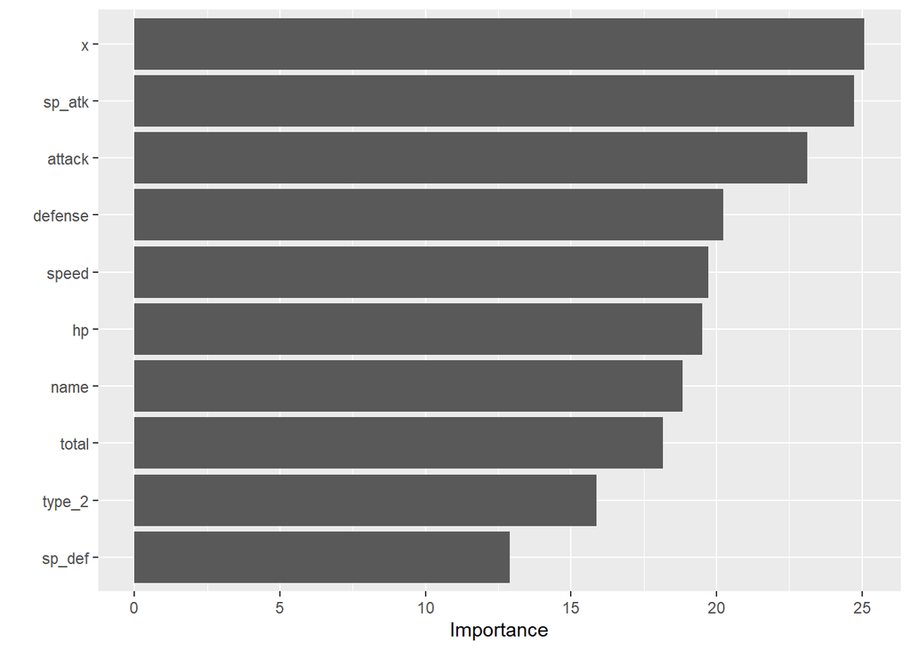

```r
rf_final_spec <- rand_forest(mtry = 7, trees = 61, min_n = 22) %>%
  set_engine("ranger", importance = "impurity") %>%
  set_mode("classification")

# fit my best_performing random forest model on the training set.
rf_final_fit <- fit(rf_final_spec, type_1 ~., data = data_train)

# visualize my best_performing pruned decision tree with the training set.
vip(rf_final_fit)
```

Which variables were most useful? Which were least useful? Are these results what you expected, or not? –> x, sp_atk, attack were most useful variables. total, type_2, sp_def were least useful variables. These results are what I expected.

### Exercise 9

Finally, set up a boosted tree model and workflow. Use the `xgboost` engine. Tune `trees`. Create a regular grid with 10 levels; let `trees` range from 10 to 2000. Specify `roc_auc` and again print an `autoplot()` of the results.

```r
boost_spec <- boost_tree(trees = tune()) %>%
  set_engine("xgboost") %>%
  set_mode("classification")


boost_wf <- workflow() %>%
  add_model(boost_spec) %>%
  add_recipe(data_recipe2)
```

```r
set.seed(1234)
param_grid3 <- grid_regular(trees(range = c(10,2000)), levels = 10)
param_grid3
```

```
## # A tibble: 10 × 1
##    trees
##    <int>
##  1    10
##  2   231
##  3   452
##  4   673
##  5   894
##  6  1115
##  7  1336
##  8  1557
##  9  1778
## 10  2000
```

```r
tune_res3 <- tune_grid(
  boost_wf,
  resamples = data_fold,
  grid = param_grid3,
  metrics = metric_set(roc_auc)
)
```

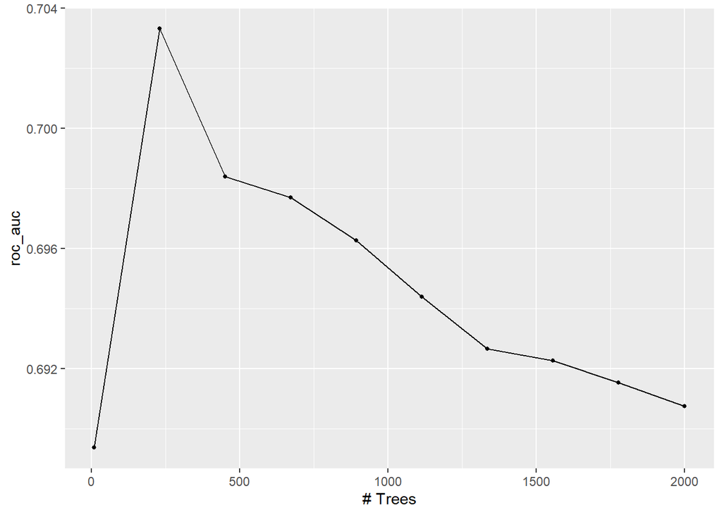

```r
autoplot(tune_res3)
```

What do you observe? –> I can observe that when ‘trees’ parameter is about 231, the model seems to yield the best performance.

What is the `roc_auc` of your best-performing boosted tree model on the folds? *Hint: Use `collect_metrics()` and `arrange()`.* –> The ‘roc_auc’ of my best-performing boosted tree model on the folds is 0.7033191.

```r
collect_metrics(tune_res3) %>%
  arrange(- mean)
```

```
## # A tibble: 10 × 7
##    trees .metric .estimator  mean     n std_err .config
##    <int> <chr>   <chr>      <dbl> <int>   <dbl> <chr>
##  1   231 roc_auc hand_till  0.703     5 0.0123  Preprocessor1_Model02
##  2   452 roc_auc hand_till  0.698     5 0.0126  Preprocessor1_Model03
##  3   673 roc_auc hand_till  0.698     5 0.0118  Preprocessor1_Model04
##  4   894 roc_auc hand_till  0.696     5 0.0118  Preprocessor1_Model05
##  5  1115 roc_auc hand_till  0.694     5 0.0115  Preprocessor1_Model06
##  6  1336 roc_auc hand_till  0.693     5 0.0119  Preprocessor1_Model07
##  7  1557 roc_auc hand_till  0.692     5 0.0123  Preprocessor1_Model08
##  8  1778 roc_auc hand_till  0.692     5 0.0122  Preprocessor1_Model09
##  9  2000 roc_auc hand_till  0.691     5 0.0123  Preprocessor1_Model10
## 10    10 roc_auc hand_till  0.689     5 0.00671 Preprocessor1_Model01
```

### Exercise 10

Display a table of the three ROC AUC values for your best-performing pruned tree, random forest, and boosted tree models. Which performed best on the folds? Select the best of the three and use `select_best()`, `finalize_workflow()`, and `fit()` to fit it to the *testing* set.

```r
m1<- collect_metrics(tune_res) %>%
  arrange(- mean)
M1<-data.frame(m1)

m2<- collect_metrics(tune_res2) %>%
  arrange(- mean)
M2<-data.frame(m2)

m3<- collect_metrics(tune_res3) %>%
  arrange(- mean)
M3<-data.frame(m3)

k1<- bind_rows(M1[1,],M2[1,],M3[1,])

# Display a table of the three ROC AUC values for your best-performing pruned tree, random forest, and boosted tree models.
k1
```

```
##   cost_complexity .metric .estimator      mean n     std_err
## 1       0.0129155 roc_auc  hand_till 0.6348932 5 0.006218214
## 2              NA roc_auc  hand_till 0.7318138 5 0.009213371
## 3              NA roc_auc  hand_till 0.7033191 5 0.012252741
##                  .config mtry trees min_n
## 1  Preprocessor1_Model06   NA    NA    NA
## 2 Preprocessor1_Model103    7    61    22
## 3  Preprocessor1_Model02   NA   231    NA
```

–> The second one, random forest model performed best on the folds.

```r
# Select the best of the three and use `select_best()`, `finalize_workflow()`, and `fit()` to fit it to the *testing* set.

best_complexity_final <- select_best(tune_res2, metric = "roc_auc")
rf_final <- finalize_workflow(rf_wf, best_complexity_final)
rf_final_fit <- fit(rf_final, data = data_test)
```

Print the AUC value of your best-performing model on the testing set. Print the ROC curves. Finally, create and visualize a confusion matrix heat map.

```r
# Print the AUC value of your best-performing model on the testing set.

predicted_data <- augment(rf_final_fit, new_data = data_test) %>%
  select(type_1, starts_with(".pred"))

predicted_data %>% roc_auc(type_1, .pred_Bug:.pred_Water)
```

```
## # A tibble: 1 × 3
##   .metric .estimator .estimate
##   <chr>   <chr>          <dbl>
## 1 roc_auc hand_till      0.986
```

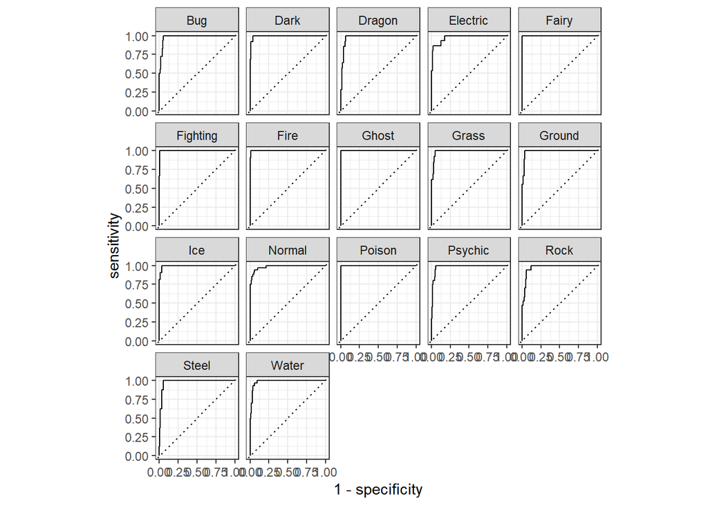

```r
#  Print the ROC curves.
predicted_data %>% roc_curve(type_1, .pred_Bug:.pred_Water) %>%
  autoplot()
```

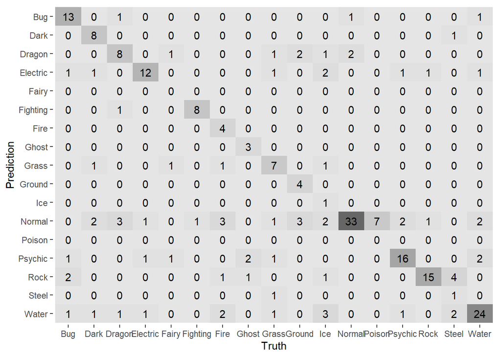

```r
# Finally, create and visualize a confusion matrix heat map.
predicted_data %>%
  conf_mat(truth = type_1, estimate = .pred_class) %>%
  autoplot(type = "heatmap")
```

## For 231 Students

### Exercise 11

Using the `abalone.txt` data from previous assignments, fit and tune a random forest model to predict `age`. Use stratified cross-validation and select ranges for `mtry`, `min_n`, and `trees`. Present your results. What was the model’s RMSE on your testing set?

```r
data_ab <- read.csv("abalone.csv")

data_ab
```

[output not shown]

[output cut: 8341 more lines]

```r
data_ab <- data_ab %>%
  mutate(age = rings + 1.5)

# splitting the data
set.seed(1234)
data_ab_split <- initial_split(data_ab, strata = "age", prop = 0.7)

data_ab_train <- training(data_ab_split)
data_ab_test <- testing(data_ab_split)

dim(data_ab_train)
```

```
## [1] 2922   10
```

```r
dim(data_ab_test)
```

```
## [1] 1255   10
```

```r
data_ab_train
```

[output not shown]

[output cut: 5831 more lines]

```r
# recipe
ab_recipe <- recipe(age ~ . , data = data_ab_train) %>%
  step_rm(rings) %>%
  step_dummy(all_nominal_predictors()) %>%
  step_interact(terms = ~ starts_with("type"):shucked_weight +
                  longest_shell:diameter +
                  shucked_weight:shell_weight) %>%
  step_normalize(all_predictors())

# model
ab_spec <- rand_forest(mtry = tune(), trees = tune(), min_n = tune()) %>%
  set_engine("ranger", importance = "impurity") %>%
  set_mode("regression")

# workflow
ab_wf <- workflow() %>%
  add_model(ab_spec) %>%
  add_recipe(ab_recipe)
```

```r
set.seed(1234)
data_ab_fold <- vfold_cv(data_ab_train, v = 5, strata = age)

set.seed(1234)
param_ab_grid <- grid_regular(mtry(range = c(1, 9)), trees(range = c(10,100)) , min_n(range = c(10,100)), levels = 8)


tune_ab_res <- tune_grid(
  ab_wf,
  resamples = data_ab_fold,
  grid = param_ab_grid,
  metrics = metric_set(rmse)
)
```

```r
best_complexity_final_ab <- select_best(tune_ab_res, metric = "rmse")
ab_rg_final <- finalize_workflow(ab_wf, best_complexity_final_ab)
ab_rg_final_fit <- fit(ab_rg_final, data = data_ab_test)

augment(ab_rg_final_fit, new_data = data_ab_test) %>%
  rmse(truth = age, estimate = .pred)
```

```
## # A tibble: 1 × 3
##   .metric .estimator .estimate
##   <chr>   <chr>          <dbl>
## 1 rmse    standard        1.78
```

–> The model’s RMSE on my testing set is ‘1.77824’.